# HW4

Lowson Li, R08323023

# 1 Strategy

1. Try to replicate the calculation from course slide.
2. Try to code by myself

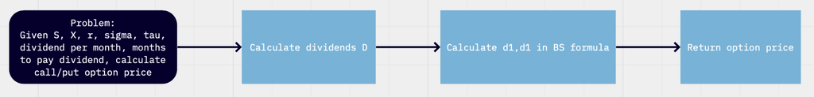

- For more details of the code and instructions, please visit my [Github](https://github.com/isthatlowsonli/Financial_Engineering)
- [Source code](https://github.com/isthatlowsonli/Financial_Engineering/blob/master/Script/HW4.Rmd)
- [Academic Portfolio](https://isthatlowsonli.github.io//Financial_Engineering/Script/practice.nb.html)

# 2 Load packages

```r
library(dplyr)
```

# 3 Question

A stock is currently priced at $75 and has a $\sigma$ of 0.35. It will pay two $1 dividends in 1 month and 4 months. If $r$ = 6%, what is the value of a European put and call option with an exercise 8 price of $65 maturing in 6 months?

# 4 Definition of BS formula

Recall the BS formula

$$c = SN(d_{1}) - Xe^{-r\tau}N(d_{2})$$

where $N(\cdot)$ is normal distribution function and

$$\begin{equation}
\begin{aligned}
d_{1} &= \frac{\mathrm{ln}(S/X)+(r+\sigma^{2}/2)\tau}{\sigma \sqrt{\tau}} \\
d_{2} &= d_{1} - \sigma \sqrt{\tau} \\
\end{aligned}
\end{equation}$$

where $r$ is usually taken as the risk-free interest rate on an investment maturaing in $\tau$ periods, at the expiration of the option contract. $\sigma$ is the annualized varianve of the rate of return on the stock, which can be estimated using historical data on stock prices or stock returns.

Consider the stock with dividends such that

$$S= D +\hat{S}$$

the new $\hat{S}$ is

$$\hat{S} = S-D$$

Given the month when dividends is pay, we can write a function to calculate the dividends

```r
dividends <- function(d_per_month, month_vec, r) {
  if (is.vector(month_vec) == TRUE) {
  D <- sum(d_per_month * exp(-r * month_vec / 12))
  return(D)
  } else{
  return(print("Check the month specification."))
  }
}
```

```r
dividends(1,c(1,4),0.06)
```

```
[1] 1.975211
```

Given he stock price $S$ is 75, the stock price $\hat{S}$ used in BS formula will be

```r
75 - dividends(1,c(1,4),0.06)
```

```
[1] 73.02479
```

Thus we can us BS formula to calculate the call option price. For put price, by put-call parity

$$\begin{equation}
\begin{aligned}
p &= c+Xe^{-r\tau}-S\\
&=Xe^{-r\tau}N(-d_{2}) -SN(-d_{1})\\
\end{aligned}
\end{equation}$$

```r
bs_opt <- function(S_hat, X, r, sigma, tau) {
  d1 <-
  (log(S_hat / X) + (r + (sigma ^ 2) / 2) * tau) / (sigma * sqrt(tau))
  d2 <- d1 - sigma * sqrt(tau)
  c <- S_hat * pnorm(d1) - X * exp(-r * tau) * pnorm(d2)
  p <- X * exp(-r * tau) * pnorm(-d2) -  S_hat * pnorm(-d1)

  return(cat("Call option price: ", c, "\n", "Put option price: ", p))
}
```

Notice that the time until maturiy is in annual base.

```r
bs_opt(73.02479,65,0.06,0.35,6/12)
```

```
Call option price:  12.80618
 Put option price:  2.860354
```

# 5 Clean version of code

```r
bs_opt <- function(S, X, r, sigma, tau, d_per_month, month_vec) {
  if (is.vector(month_vec) == TRUE) {
    D <- sum(d_per_month * exp(-r * month_vec / 12))
    S_hat <- S - D
    d1 <-
      (log(S_hat / X) + (r + (sigma^2) / 2) * tau) / (sigma * sqrt(tau))
    d2 <- d1 - sigma * sqrt(tau)
    c <- S_hat * pnorm(d1) - X * exp(-r * tau) * pnorm(d2)
    p <- X * exp(-r * tau) * pnorm(-d2) - S_hat * pnorm(-d1)
    return(cat("Call option price: ", c, "\n", "Put option price: ", p))
  } else {
    return(print("Check the month specification."))
  }
}
```

```r
bs_opt(
  S = 75, # current price
  X = 65, # strike price
  r = 0.06, # continuously-compounded one-period interest rate
  sigma = 0.35, # annualized variance of the rate of return on the stock
  tau = 6 / 12, # time until maturity, annualized
  d_per_month = 1, # dividends per month
  month_vec = c(1, 4) # vector of month with dividends
  )
```

```
Call option price:  12.80618
 Put option price:  2.860355
```